# Sobre-educación 2: moda y `ocupacion1`

# Introducción

Este documento es la continuación de:

1. C:/Prog/tesis/1_Primeros_pasos.Rmd
2. C:/Prog/tesis/INEGI-2023_Conociendo-ENOE.Rmd
3. C:/Prog/tesis/2_Analisis_exploratorio_datos1.Rmd
4. C:/Prog/tesis/3_Limpieza_datos.Rmd
5. C:/Prog/tesis/4_Panorama_jovenes.Rmd
6. C:/Prog/tesis/5_Sobre-educacion.Rmd

Se determinará la sobre-educación mediante el método de la moda con `ocupacion1`, asimismo se tratará de responder algunas preguntas de investigación.

# Paquetes requeridos

```r
library(tidyverse)
```

```r
# paleta de colores p. 422
library(RColorBrewer)
# letter value plot p. 99 (inglés)
library(lvplot)
# calcular la moda
library(DescTools)
# coeficiente de asimetría
library(moments)
library(EnvStats)
# # 1. vivienda
# viv <- read_csv(
#   "enoet22025/ENOE_VIVT225.csv",
#   col_types = cols(.default = col_character())
# )

# # 2. hogar
# hog <- read_csv(
#   "enoet22025/ENOE_HOGT225.csv",
#   col_types = cols(.default = col_character())
# )

# 3. sociodemográfica
sdem <- read_csv(
  "enoet22025/ENOE_SDEMT225.csv",
  col_types = cols(.default = col_character())
)

# 4. ocupación y empleo I
coe1 <- read_csv(
  "enoet22025/ENOE_COE1T225.csv",
  col_types = cols(.default = col_character())
)

# 5. ocupación y empleo II
coe2 <- read_csv(
  "enoet22025/ENOE_COE2T225.csv",
  col_types = cols(.default = col_character())
)

# segmentación
sdem<- sdem %>% mutate(
  # edad
  eda = as.integer(eda),
  # años de escolaridad
  anios_esc = as.integer(anios_esc),
  # 99 pasa a NA para evitar 99 - edu_req
  anios_esc = if_else(anios_esc != 99, anios_esc, NA),
  # ponderador trimestral
  fac_tri = as.double(fac_tri),
  # ingreso mensual
  ingocup = as.double(ingocup),
  # promedio de ingreso por hora
  ing_x_hrs = as.double(ing_x_hrs)
)

# grupos de edad
sdem <- sdem %>%
  mutate(
    edad_7g = case_when(
      between(eda, 0, 14) ~ "1",
      between(eda, 15, 24) ~ "2",
      between(eda, 25, 34) ~ "3",
      between(eda, 35, 44) ~ "4",
      between(eda, 45, 54) ~ "5",
      between(eda, 55, 64) ~ "6",
      between(eda, 65, 97) ~ "7",
      # edad no especificada mayores a 12
      eda == "98" ~ "98",
      # edad no especificada menores a 12
      eda == "99" ~ "99",
      # NA sin comillas para valores faltantes
      TRUE ~ NA
    )
  )

# carreras universitarias
sdem <- sdem %>%
  mutate(
    carrera1 = if_else(str_length(cs_p14_c) == 5, str_c("0", cs_p14_c), cs_p14_c),
    carrera2 = if_else(str_length(cs_p14_c) == 5, str_c("0", cs_p14_c), cs_p14_c),
    carrera3 = if_else(str_length(cs_p14_c) == 5, str_c("0", cs_p14_c), cs_p14_c)
  ) %>%
  separate(
    carrera1,
    # campo amplio
    into = c("carrera1", "res"),
    sep = 2
  ) %>%
  separate(
    carrera2,
    # campo específico
    into = c("carrera2", "res"),
    sep = 3
  ) %>%
  separate(
    carrera3,
    # campo detallado
    into = c("carrera3", "res"),
    sep = 4
  ) %>%
  select(-res)

# grupos ocupacionales
coe1 <- coe1 %>%
  mutate(
    ocupacion1 = p3,
    ocupacion2 = p3
  ) %>%
  separate(
    ocupacion1,
    into = c("ocupacion1", "res"),
    sep = 1
  ) %>%
  separate(
    ocupacion2,
    into = c("ocupacion2", "res"),
    sep = 2
  ) %>%
  select(-res)

# población total
pob_total <- sdem %>%
  filter(
    r_def == "0",
    # es igual a (c_res == "1" | c_res == "3")
    c_res != "2"
  )

# población de 12 y más para unir sdem y coe
pob_12ymas <- sdem %>%
  filter(
  r_def == "0",
  c_res != "2",
  between(eda, 12, 98)
  )

# unión de sdem y coe
completo <- pob_12ymas %>%
  full_join(coe1, by = c("tipo", "mes_cal", "ent", "con", "v_sel", "n_hog", "h_mud", "n_ren")) %>%
  full_join(coe2, by = c("tipo", "mes_cal", "ent", "con", "v_sel", "n_hog", "h_mud", "n_ren"))

# población de 15 años y más
pob_15ymas <- completo %>%
  filter(
    r_def.x == "0",
    c_res != "2",
    between(eda.x, 15, 98)
  )

# INEGI(2023: 21)
ocupada <- pob_15ymas %>%
  filter(clase2 == 1)

# INEGI(2023: 25)
desocupada <- pob_15ymas %>%
  filter(clase2 == 2)

# INEGI(2023: 26)
pnea <- pob_15ymas %>%
  filter(clase1 == 2)

# escolaridad requerida con la moda
edu_req <- ocupada %>%
  group_by(ocupacion1, anios_esc) %>%
  summarise(tot = sum(fac_tri.x)) %>%
  filter(tot == max(tot)) %>%
  rename("moda" = "anios_esc") %>%
  select(-tot)
# variable de education mismatch
ocupada <- left_join(ocupada, edu_req, by = "ocupacion1") %>%
  mutate(
    edu_mis = case_when(
      # overeducation
      anios_esc > moda ~ 1,
      # undereducation
      anios_esc < moda ~ 2,
      # required
      TRUE ~ 0
    )
  )

# # profesionistas
# profesionistas <- pob_15ymas %>%
#   filter(
#     cs_p13_1 == "7" | cs_p13_1 == "8" | cs_p13_1 == "9"
#   )
#
# # jovenes
# jovenes <- pob_15ymas %>%
#   filter(edad_7g == "3")
```

# Construcción de años de educación requeridos

## Con `ocupacion1`

```r
completo %>%
  group_by(ocupacion1, anios_esc) %>%
  summarise(tot = sum(fac_tri.x)) %>%
  filter(tot == max(tot)) %>%
  rename("edu_req" = "anios_esc") %>%
  select(-tot)
```

| ocupacion1 | edu_req |
| --- | --- |
| 1 | 16 |
| 2 | 16 |
| 3 | 12 |
| 4 | 12 |
| 5 | 9 |
| 6 | 6 |
| 7 | 9 |
| 8 | 9 |
| 9 | 9 |
| NA | 9 |

## Valores `NA`

¿Cuántos valores `NA` existen en `ocupacion1`?

```r
completo %>%
  group_by(ocupacion1) %>%
  summarise(tot = sum(fac_tri.x)) %>%
  mutate(prop = tot / sum(tot))
```

| ocupacion1 | tot | prop |
| --- | --- | --- |
| 1 | 2096131 | 0.01914223 |
| 2 | 10599890 | 0.09680004 |
| 3 | 4109336 | 0.03752717 |
| 4 | 8608206 | 0.07861164 |
| 5 | 5343756 | 0.04880011 |
| 6 | 3871362 | 0.03535395 |
| 7 | 6340810 | 0.05790538 |
| 8 | 6573434 | 0.06002974 |
| 9 | 12285082 | 0.11218951 |
| NA | 49674942 | 0.45364022 |

¡Los valores `NA` representan el 45% de la muestra! ¿De dónde vendrán? ¿Serán PEA o PNEA?

```r
completo %>%
  group_by(clase1) %>%
  summarise(tot = sum(fac_tri.x)) %>%
  mutate(prop = tot / sum(tot))
```

| clase1 | tot | prop |
| --- | --- | --- |
| 1 | 61457572 | 0.5612413 |
| 2 | 48045377 | 0.4387587 |

El 56% de la muestra es PEA, mientras que el 44% son PNEA que representa una población de 48,045,377. Hagamos un cruce de `ocupacion1` y `clase1`.

```r
completo %>%
  group_by(ocupacion1, clase1) %>%
  summarise(tot = sum(fac_tri.x))
```

| ocupacion1 | clase1 | tot |
| --- | --- | --- |
| 1 | 1 | 2096131 |
| 2 | 1 | 10599890 |
| 3 | 1 | 4109336 |
| 4 | 1 | 8608206 |
| 5 | 1 | 5343756 |
| 6 | 1 | 3871362 |
| 7 | 1 | 6340810 |
| 8 | 1 | 6573434 |
| 9 | 1 | 12285082 |
| NA | 1 | 1629565 |

[output cut: 1 more lines]

Se observa que del valor `NA` de `ocupacion1` proviene tanto de PEA como de PNEA, en el segundo caso coincide con el total de PNEA (48,045,377). Quizá en el caso de PEA sea la población desocupada, validemos con `clase2`.

```r
completo %>%
  group_by(ocupacion1, clase2) %>%
  summarise(tot = sum(fac_tri.x))
```

| ocupacion1 | clase2 | tot |
| --- | --- | --- |
| 1 | 1 | 2096131 |
| 2 | 1 | 10599890 |
| 3 | 1 | 4109336 |
| 4 | 1 | 8608206 |
| 5 | 1 | 5343756 |
| 6 | 1 | 3871362 |
| 7 | 1 | 6340810 |
| 8 | 1 | 6573434 |
| 9 | 1 | 12285082 |
| NA | 2 | 1629565 |

[output cut: 2 more lines]

En efecto, la PEA que aparece en el valor `NA` de `ocupacion1` pertenece a la población desocupada. Entonces, para construir los años requeridos en cada grupo ocupacional puedo eliminar el valor `NA` de `ocupacion1`, ¿cómo? en línea con INEGI (2023) p. 21 debe aplicarse el criterio general más algunos criterios específicos, según la población de estudio.

# Construcción de tabla `pob_15ynas`

Recordemos que el criterio general es:

```
R_DEF=’00’ AND (C_RES=’1’ OR C_RES=’3’) AND (EDA>=’15’ AND EDA<=’98’)
```

Dicho criterio lo tiene aplicado la tabla `pob_15ymas`, sin embargo no tiene las variables asociadas a los grupos ocupacionales aquellos recae en la tabla `completo` que se construyó a partir de `pob_12ymas` en la cual se utilizó el siguiente criterio:

```
R_DEF=’00’ AND (C_RES=’1’ OR C_RES=’3’) AND (EDA>=’12’ AND EDA<=’98’)
```

Entonces, ¿qué hacer? en primer lugar se valida las edades en la tabla `completo`

```r
completo %>%
  group_by(eda.x) %>%
  summarise(tot = sum(fac_tri.x))
```

| eda.x | tot |
| --- | --- |
| 12 | 2239317 |
| 13 | 2351966 |
| 14 | 2296466 |
| 15 | 2320958 |
| 16 | 2287634 |
| 17 | 2354171 |
| 18 | 2293250 |
| 19 | 2117009 |
| 20 | 2042975 |
| 21 | 1981961 |

[output cut: 77 more lines]

Se valida si en edades menos a 15 años, existan registros en `ocupacion1`

```r
completo %>%
  group_by(eda.x, ocupacion1) %>%
  summarise(tot = sum(fac_tri.x)) %>%
  group_by(eda.x) %>%
  mutate(prop = tot / sum(tot) * 100)
```

| eda.x | ocupacion1 | tot | prop |
| --- | --- | --- | --- |
| 12 | 2 | 1092 | 0.048764869 |
| 12 | 3 | 341 | 0.015227857 |
| 12 | 4 | 11601 | 0.518059748 |
| 12 | 5 | 2812 | 0.125574003 |
| 12 | 6 | 4055 | 0.181082000 |
| 12 | 7 | 2905 | 0.129727055 |
| 12 | 8 | 1473 | 0.065778985 |
| 12 | 9 | 45685 | 2.040130986 |
| 12 | NA | 2169353 | 96.875654496 |
| 13 | 2 | 982 | 0.041752304 |

[output cut: 790 more lines]

La proporción de valores `NA` en edades menores a 15 años se encuentra alrededor del 90%, es decir, SI existen observaciones en `ocupacion1` que tienen edades menores a 15 años. Se valida datos con INEGI (2025).

```r
# pob 15 y más
completo %>%
  summarise(tot = sum(fac_tri.x))
```

| tot |
| --- |
| 109502949 |

```r
# pea y pnea
completo %>%
  group_by(clase1) %>%
  summarise(tot = sum(fac_tri.x))
```

| clase1 | tot |
| --- | --- |
| 1 | 61457572 |
| 2 | 48045377 |

En INEGI (2025) p. 7 tienen los siguentes resultados:

- Población de 15 años y más: 102.6
- PEA: 61.1
- PNEA: 41.6

Es decir, los resultados NO coinciden.

¿Cómo solucionarlo? Crear la tabla `pob_15ymas` después de unir las tablas `sdem` y `coe`, se realiza modificación en el *chunk* (bloque) `setup`. Se vuelve a validar resultados.

```r
# pob 15 y más
pob_15ymas %>%
  summarise(tot = sum(fac_tri.x))
```

| tot |
| --- |
| 102615200 |

```r
# pea y pnea
pob_15ymas %>%
  group_by(clase1) %>%
  summarise(tot = sum(fac_tri.x))
```

| clase1 | tot |
| --- | --- |
| 1 | 61065005 |
| 2 | 41550195 |

Los resultados ya coinciden con INEGI (2025) p. 7

# Construcción de años de educación requeridos (2)

Entonces, construyo los años de educación requeridos eliminando el valor `NA` de `ocupacion1` con la tabla `pob_15ymas`.

```r
pob_15ymas %>%
  filter(!is.na(ocupacion1) & anios_esc != 99) %>%
  group_by(ocupacion1, anios_esc) %>%
  summarise(tot = sum(fac_tri.x)) %>%
  filter(tot == max(tot)) %>%
  ungroup() %>%
  mutate(prop = tot / sum(tot)) %>%
  rename("edu_req" = "anios_esc")
```

| ocupacion1 | edu_req | tot | prop |
| --- | --- | --- | --- |
| 1 | 16 | 618549 | 0.03297949 |
| 2 | 16 | 3031187 | 0.16161535 |
| 3 | 12 | 1326915 | 0.07074781 |
| 4 | 12 | 2501032 | 0.13334880 |
| 5 | 9 | 1568806 | 0.08364483 |
| 6 | 6 | 1001713 | 0.05340884 |
| 7 | 9 | 2149272 | 0.11459383 |
| 8 | 9 | 2433924 | 0.12977077 |
| 9 | 9 | 4124166 | 0.21989027 |

# Construcción de tabla `ocupada`

Duda, ¿porcentaje del valor `99` en `anios_esc`?

```r
pob_15ymas %>%
  group_by(anios_esc) %>%
  summarise(tot = sum(fac_tri.x)) %>%
  mutate(prop = tot / sum(tot) * 100)
```

| anios_esc | tot | prop |
| --- | --- | --- |
| 0 | 4477124 | 4.363022e+00 |
| 1 | 755645 | 7.363870e-01 |
| 2 | 1737607 | 1.693323e+00 |
| 3 | 2459065 | 2.396394e+00 |
| 4 | 1123478 | 1.094846e+00 |
| 5 | 877447 | 8.550848e-01 |
| 6 | 13194997 | 1.285872e+01 |
| 7 | 917565 | 8.941804e-01 |
| 8 | 2506130 | 2.442260e+00 |
| 9 | 24729933 | 2.409968e+01 |

[output cut: 16 more lines]

El valor `99` representa apenas el 0.2% del total de observaciones en `anios_esc`, pero se decide eliminar valor debido a que una persona que contestó no saber sus años de escolaridad no se puede saber si está o no sobre-educado: ¿`99 > edu_req`? Entonces, se decide convertir el valor `99` a `NA` para simplificar las líneas de código; esto se realiza en el bloque `setup`.

Total de población de 15 años y más

```r
pob_15ymas %>%
  summarise(tot = sum(fac_tri.x))
```

| tot |
| --- |
| 102615200 |

```r
pob_15ymas %>%
  filter(!is.na(ocupacion1)) %>%
  summarise(tot = sum(fac_tri.x))
```

| tot |
| --- |
| 59440760 |

Se observa que el número es equivalente a la población ocupada, véase INEGI (2025) p. 7. Entonces, se debe crear una tabla que contenga `ocupados`. Se realiza en el bloque `setup`.

```r
ocupada %>%
  summarise(tot = sum(fac_tri.x))
```

| tot |
| --- |
| 59440760 |

Entonces, ya no existe valores `NA` en `ocupacion1`.

# Construcción de educación requerida (3) con la moda

```r
ocupada %>%
  group_by(ocupacion1) %>%
  summarise(tot = sum(fac_tri.x))
```

| ocupacion1 | tot |
| --- | --- |
| 1 | 2096131 |
| 2 | 10595180 |
| 3 | 4103695 |
| 4 | 8542403 |
| 5 | 5319575 |
| 6 | 3839458 |
| 7 | 6327740 |
| 8 | 6565616 |
| 9 | 12050962 |

Se determinan los años de escolaridad requeridos por ocupación mediante el método de la moda, se realiza en el bloque de configuración (`setup`)

# Incidencia

```r
# incidencia
ocupada %>%
  group_by(edu_mis) %>%
  summarise(tot = sum(fac_tri.x)) %>%
  mutate(prop = tot / sum(tot))
```

| edu_mis | tot | prop |
| --- | --- | --- |
| 0 | 18906342 | 0.3180703 |
| 1 | 21161735 | 0.3560139 |
| 2 | 19372683 | 0.3259158 |

Se observa que la población ocupada de 15 años y más, el 35% está sobre-educada, mientras que el 32% está infra-educada y con una educación acorde al puesto.

## Por sexo

```r
ocupada %>%
  group_by(sex, edu_mis) %>%
  summarise(tot = sum(fac_tri.x)) %>%
  mutate(prop = tot / sum(tot))
```

```
## argument.
```

| sex | edu_mis | tot | prop |
| --- | --- | --- | --- |
| 1 | 0 | 10764719 | 0.3066006 |
| 1 | 1 | 12662648 | 0.3606574 |
| 1 | 2 | 11682542 | 0.3327420 |
| 2 | 0 | 8141623 | 0.3346214 |
| 2 | 1 | 8499087 | 0.3493132 |
| 2 | 2 | 7690141 | 0.3160654 |

Del total de mujeres y hombres, el 35% y el 36% está sobre-educado, respectivamente. (valor 1).

```r
ocupada %>%
  group_by(edu_mis, sex) %>%
  summarise(tot = sum(fac_tri.x)) %>%
  mutate(prop = tot / sum(tot))
```

| edu_mis | sex | tot | prop |
| --- | --- | --- | --- |
| 0 | 1 | 10764719 | 0.5693708 |
| 0 | 2 | 8141623 | 0.4306292 |
| 1 | 1 | 12662648 | 0.5983748 |
| 1 | 2 | 8499087 | 0.4016252 |
| 2 | 1 | 11682542 | 0.6030420 |
| 2 | 2 | 7690141 | 0.3969580 |

Del total de sobre-educados, el 60% son hombres.

Comprobación

```r
comprob <- ocupada %>%
  group_by(sex) %>%
  summarise(tot = sum(fac_tri.x)) %>%
  mutate(prop = tot / sum(tot)) %>%
  rename("prop_tot" = "prop")

ocupada %>%
  group_by(edu_mis, sex) %>%
  summarise(tot = sum(fac_tri.x)) %>%
  mutate(prop = tot / sum(tot)) %>%
  filter(edu_mis == 0) %>%
  rename(
    "over" = "tot",
    "prop_over" = "prop"
  ) %>%
  left_join(comprob, by = "sex")
```

| edu_mis | sex | over | prop_over | tot | prop_tot |
| --- | --- | --- | --- | --- | --- |
| 0 | 1 | 10764719 | 0.5693708 | 35109909 | 0.5906706 |
| 0 | 2 | 8141623 | 0.4306292 | 24330851 | 0.4093294 |

## Por grupos de edad

```r
ocupada %>%
  group_by(edad_7g, edu_mis) %>%
  summarise(tot = sum(fac_tri.x)) %>%
  mutate(prop = tot / sum(tot))
```

| edad_7g | edu_mis | tot | prop |
| --- | --- | --- | --- |
| 2 | 0 | 2708035 | 0.3118559 |
| 2 | 1 | 3580716 | 0.4123533 |
| 2 | 2 | 2394860 | 0.2757908 |
| 3 | 0 | 4566734 | 0.3337661 |
| 3 | 1 | 6295785 | 0.4601361 |
| 3 | 2 | 2819921 | 0.2060978 |
| 4 | 0 | 4806468 | 0.3486335 |
| 4 | 1 | 5160488 | 0.3743120 |
| 4 | 2 | 3819638 | 0.2770545 |
| 5 | 0 | 4128167 | 0.3420856 |

[output cut: 11 more lines]

En el grupo de 25 a 34 años (valor 3) el 46% está sobre-educado.

De forma gráfica

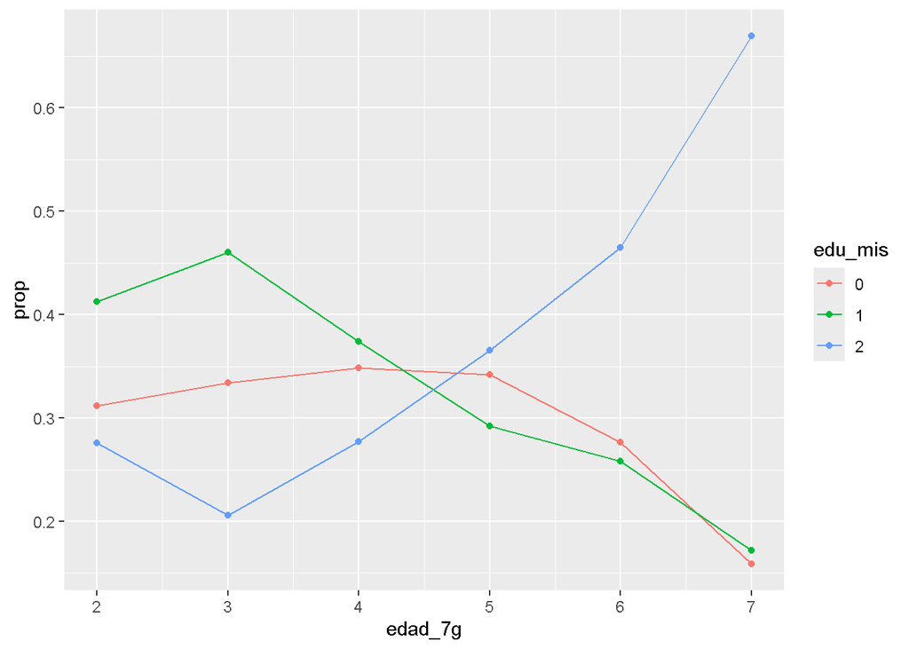

```r
ocupada %>%
  filter(edad_7g != 98) %>%
  mutate(
    edad_7g = as.integer(edad_7g),
    edu_mis = factor(edu_mis)
  ) %>%
  group_by(edad_7g, edu_mis) %>%
  summarise(tot = sum(fac_tri.x)) %>%
  mutate(prop = tot / sum(tot)) %>%
  ggplot(aes(edad_7g, prop, color = edu_mis)) +
  geom_point() +
  geom_line()
```

## Por edad

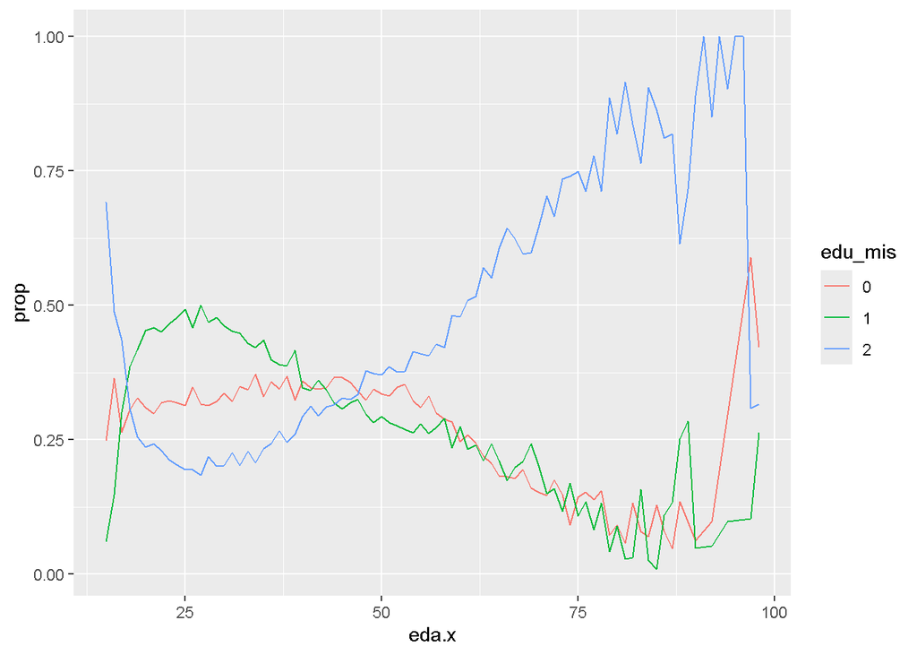

```r
ocupada %>%
  mutate(edu_mis = factor(edu_mis)) %>%
  group_by(eda.x, edu_mis) %>%
  summarise(tot = sum(fac_tri.x)) %>%
  mutate(prop = tot / sum(tot)) %>%
  ggplot(aes(eda.x, prop, color = edu_mis)) +
  geom_line()
```

Con respecto a la sobre-educación, se observa que alcanza un techo del 50% alrededor de los 25 años para disminuir paulatinamente, excepto después de los 75 años donde vuelve a incrementarse hasta un 25%. Por otra parte, la infra-educación tiene una proporción elevada a incios de la edad laboral pero también a finales de la misma, esto último como señala la evidencia empírica.

## Por nivel de estudios

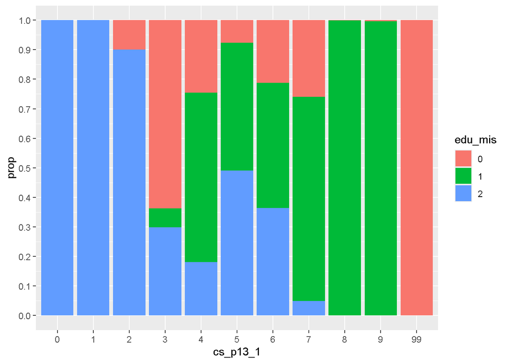

```r
ocupada %>%
  mutate(edu_mis = factor(edu_mis)) %>%
  group_by(cs_p13_1, edu_mis) %>%
  summarise(tot = sum(fac_tri.x)) %>%
  mutate(prop = tot / sum(tot)) %>%
  ggplot(aes(cs_p13_1, prop, fill = edu_mis)) +
  geom_col() +
  scale_y_continuous(breaks = seq(0, 1, by = 0.1))
```

En los grados escolares básicos, el 100% se encuentra infra-educado, en cuanto a licenciatura alrededor del 70% está sobre-educado y para el caso de maestría y doctorado el 100% se encuentra sobre-educado.

Con `anios_esc`

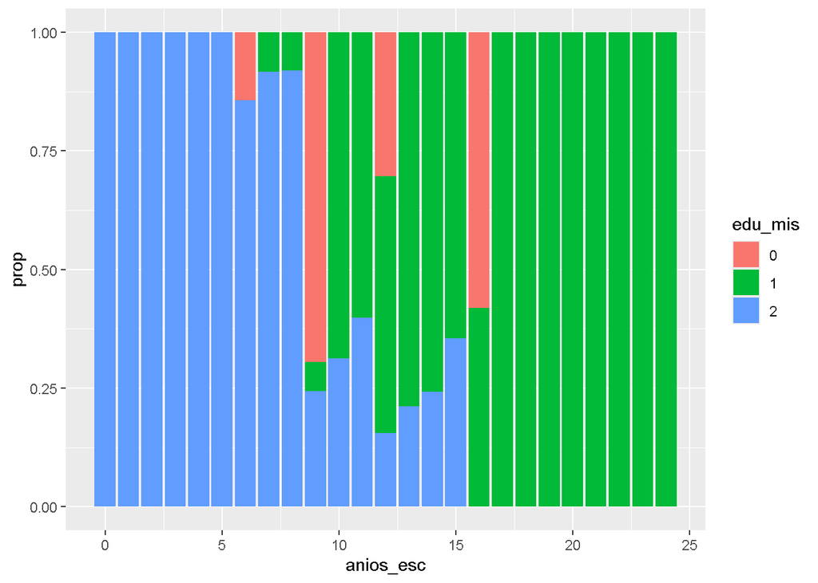

```r
ocupada %>%
  mutate(edu_mis = factor(edu_mis)) %>%
  group_by(anios_esc, edu_mis) %>%
  summarise(tot = sum(fac_tri.x)) %>%
  mutate(prop = tot / sum(tot)) %>%
  ggplot(aes(anios_esc, prop, fill = edu_mis)) +
  geom_col()
```

## Por carreras

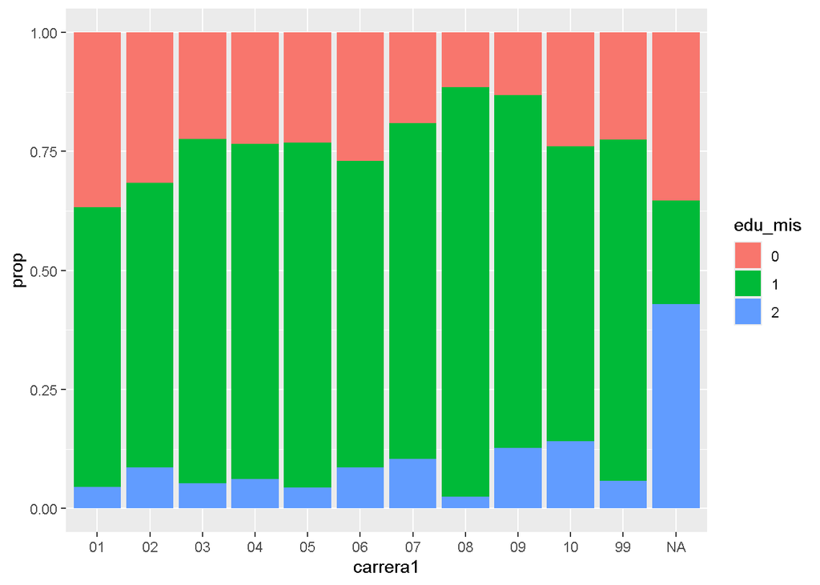

```r
ocupada %>%
  group_by(carrera1, edu_mis) %>%
  summarise(tot = sum(fac_tri.x)) %>%
  mutate(
    prop = tot / sum(tot),
    edu_mis = factor(edu_mis)
  ) %>%
  ggplot(aes(carrera1, prop, fill = edu_mis)) +
  geom_col()
```

## Por ocupaciones

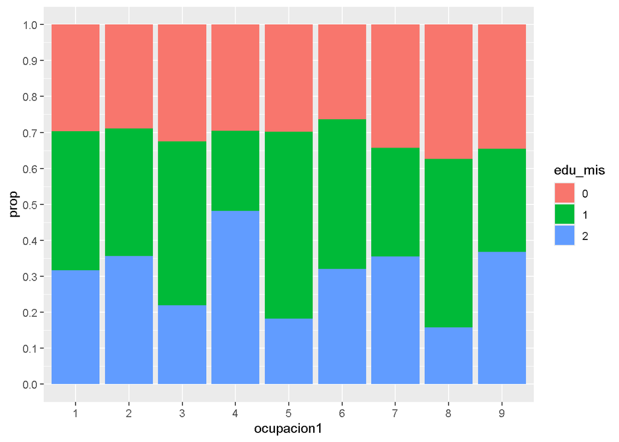

```r
ocupada %>%
  mutate(edu_mis = factor(edu_mis)) %>%
  group_by(ocupacion1, edu_mis) %>%
  summarise(tot = sum(fac_tri.x)) %>%
  mutate(prop = tot / sum(tot)) %>%
  ggplot(aes(ocupacion1, prop, fill = edu_mis)) +
  geom_col() +
  scale_y_continuous(breaks = seq(0, 1, by = 0.1))
```

En el grupo “3 Trabajadores auxiliares en actividades administrativas”, “5 Trabajadores en servicios personales y de vigilancia” y “8 Operadores de maquinaria industrial, ensambladores, choferes y conductores de transporte” alrededor del 50% está sobre-educado.

## Por entidad federativa

```
## argument.
```

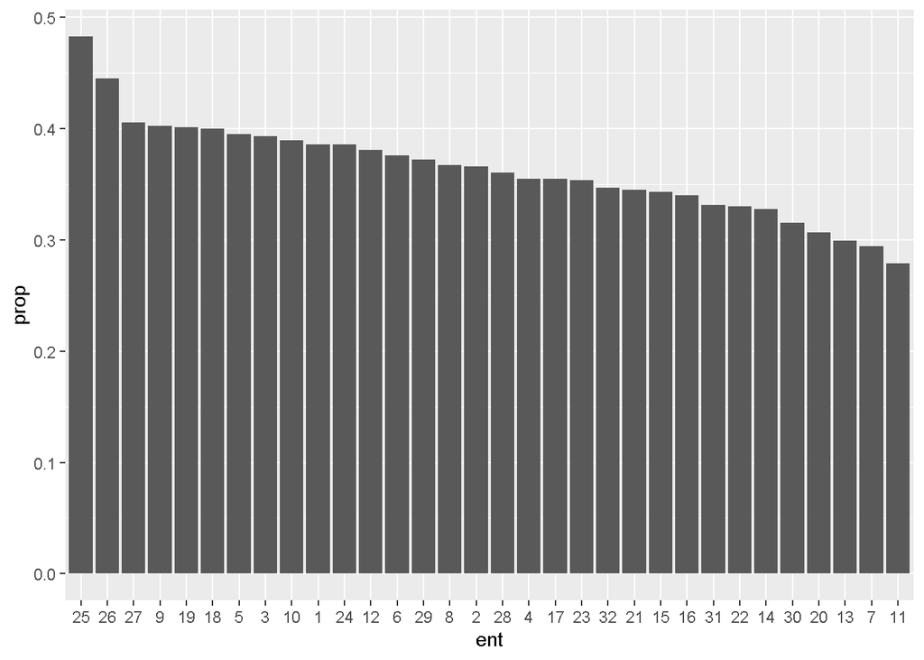

```r
ocupada %>%
  group_by(ent, edu_mis) %>%
  summarise(tot = sum(fac_tri.x)) %>%
  mutate(
    prop = tot/ sum(tot)
    ) %>%
  filter(edu_mis == 1) %>%
  ungroup() %>%
  mutate(
    ent = factor(ent),
    ent = fct_reorder(ent, -prop)
  ) %>%
  ggplot(aes(ent, prop)) +
  geom_col()
```

En Sinaloa (25), Sonora (26) y Tabasco (27) existe la mayor cantidad de sobre-educados, alrededor del 40%.

### Profesionistas

```
## argument.
```

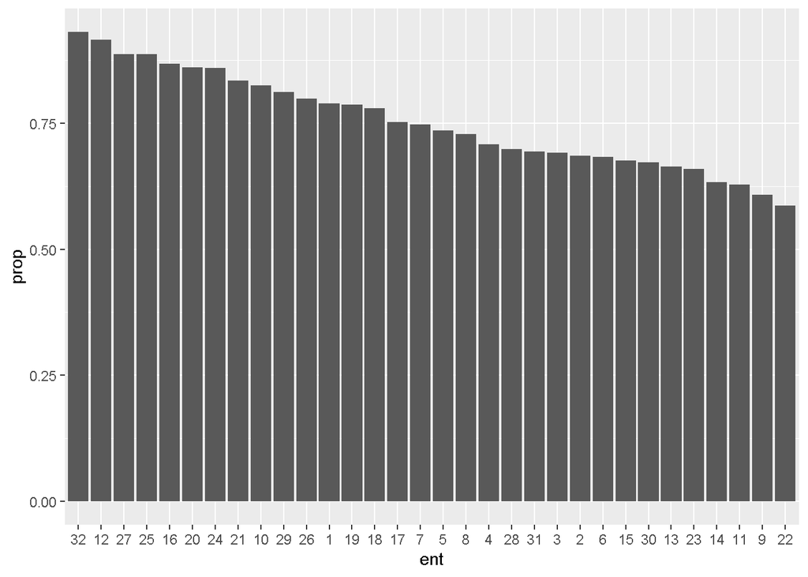

```r
ocupada %>%
  filter(cs_p13_1 == 7 | cs_p13_1 == 8 | cs_p13_1 == 9) %>%
  group_by(ent, edu_mis) %>%
  summarise(tot = sum(fac_tri.x)) %>%
  mutate(
    prop = tot/ sum(tot)
    ) %>%
  filter(edu_mis == 1) %>%
  ungroup() %>%
  mutate(
    ent = factor(ent),
    ent = fct_reorder(ent, -prop)
  ) %>%
  ggplot(aes(ent, prop)) +
  geom_col()
```

En el caso de profesionistas, Zacatecas (32), Guerrero (12), y Tabasco (27) son los estados con el mayor número de profesionistas sobre-educados (por encima del 75%), mientras que Guanajuato (11), Ciudad de México (9), y Querétaro (22) son los que tienen la menor proporción, no obstante aún en esos casos el porcentaje es superior al 50%.

# Años de escolaridad por estados

¿Cuáles son los estados con el mayor número de años de escolaridad?

## Media

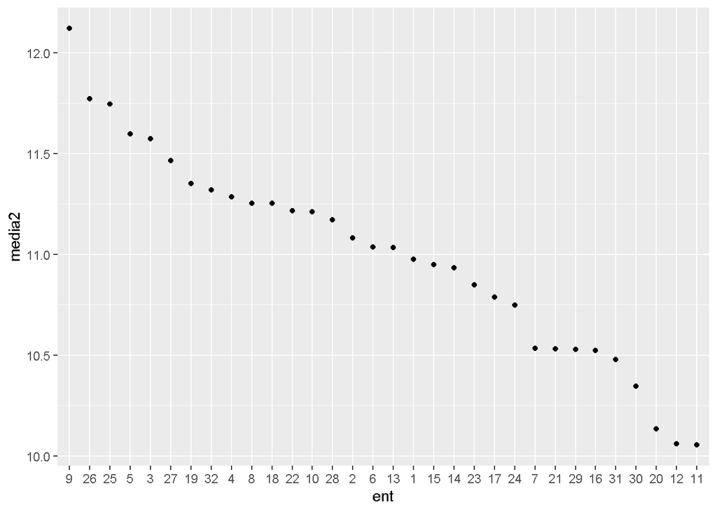

```r
ocupada %>%
  filter(cs_p13_1 != 99 & !is.na(anios_esc)) %>%
  mutate(cs_p13_1 = as.integer(cs_p13_1)) %>%
  group_by(ent) %>%
  summarise(
    media1 = mean(cs_p13_1),
    media2 = mean(anios_esc)
  ) %>%
  mutate(
    ent = factor(ent),
    ent = fct_reorder(ent, -media2)
  ) %>%
  ggplot(aes(ent, media2)) +
  geom_point()
```

Ciudad de México, Sonora y Sinaloa son los estados con el mayor número de años escolares.

## Mediana

¿Cuál es la mediana de años de estudio?

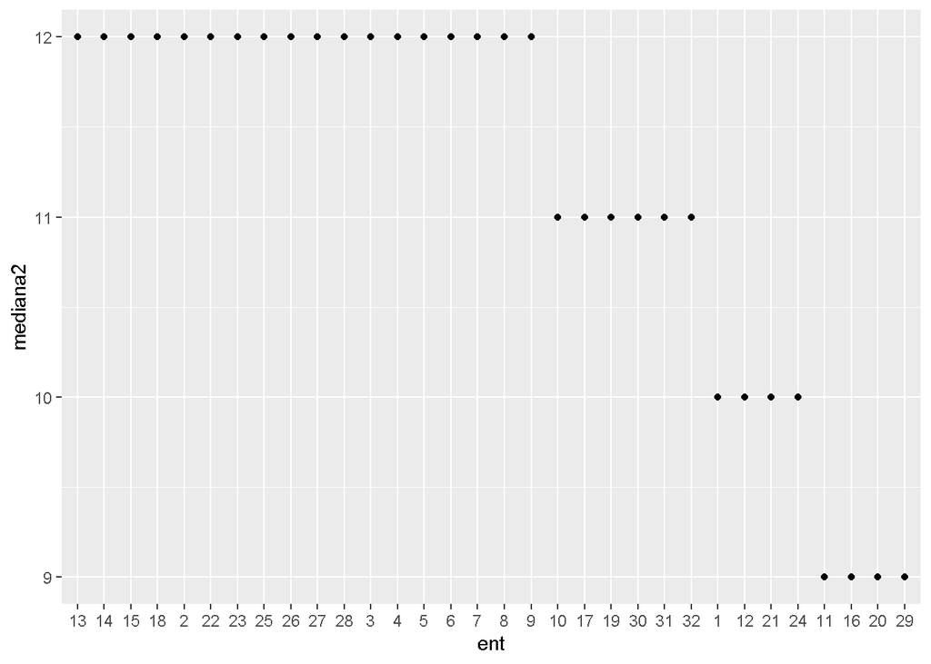

```r
ocupada %>%
  filter(cs_p13_1 != 99 & !is.na(anios_esc)) %>%
  mutate(cs_p13_1 = as.integer(cs_p13_1)) %>%
  group_by(ent) %>%
  summarise(
    mediana1 = median(cs_p13_1),
    mediana2 = median(anios_esc)
  ) %>%
  mutate(
    ent = factor(ent),
    ent = fct_reorder(ent, -mediana2)
  ) %>%
  ggplot(aes(ent, mediana2)) +
  geom_point()
```

## Moda

¿Cuál es la moda de años de estudio?

```
## argument.
```

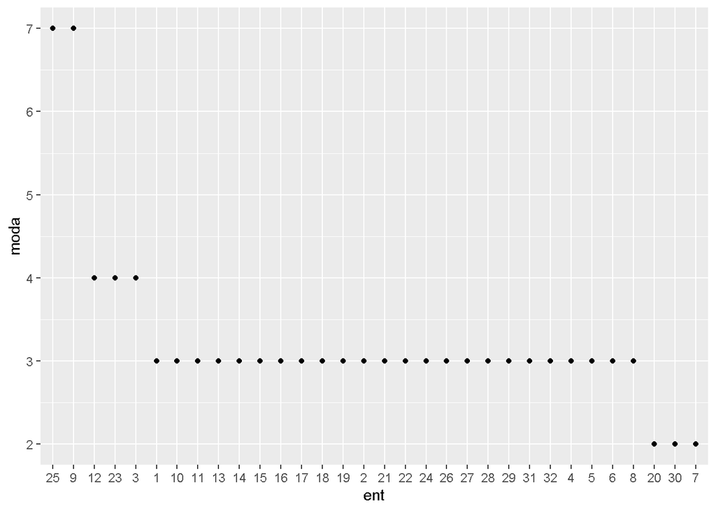

```r
ocupada %>%
  filter(cs_p13_1 != 99 & !is.na(anios_esc)) %>%
  mutate(cs_p13_1 = as.integer(cs_p13_1)) %>%
  group_by(ent, cs_p13_1) %>%
  summarise(tot = sum(fac_tri.x)) %>%
  filter(tot == max(tot)) %>%
  ungroup() %>%
  rename("moda" = "cs_p13_1") %>%
  mutate(
    ent = factor(ent),
    ent = fct_reorder(ent, -moda)
  ) %>%
  ggplot(aes(ent, moda)) +
  geom_point()
```

Parece que existe una relación positiva entre mayores años de estudio y mayor proporción de sobre-educados por entidad federativa, ¿cómo validarlo?

# Relación entre años de estudio y sobre-educación

Con la media

```r
comprob1 <- ocupada %>%
  filter(cs_p13_1 != 99 & !is.na(anios_esc)) %>%
  mutate(cs_p13_1 = as.integer(cs_p13_1)) %>%
  group_by(ent) %>%
  summarise(
    media1 = mean(cs_p13_1),
    media2 = mean(anios_esc)
  )

comprob2 <- ocupada %>%
  group_by(ent, edu_mis) %>%
  summarise(tot = sum(fac_tri.x)) %>%
  mutate(
    prop = tot/ sum(tot)
    ) %>%
  filter(edu_mis == 1)
```

```
## argument.
```

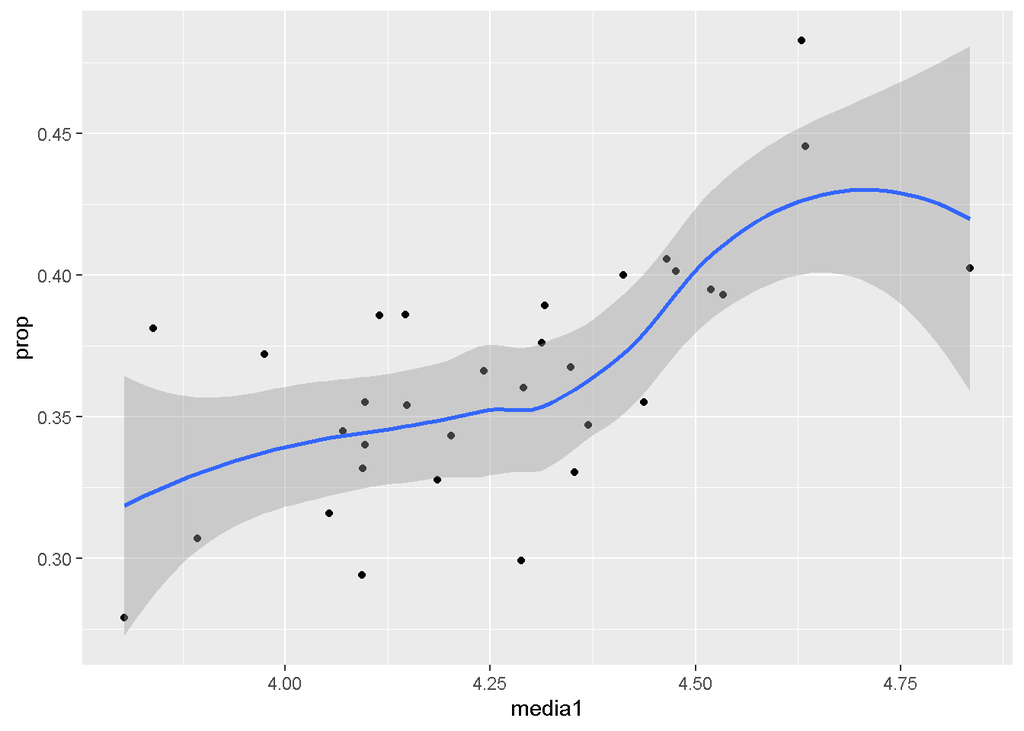

```r
full_join(comprob1, comprob2, by = "ent") %>%
  ggplot(aes(media1, prop)) +
  geom_point() +
  geom_smooth()
```

Se observa una relación positiva entre los años escolares y la proporción de sobre-educados, es decir, a mayor año escolar aumenta la proporción de personas sobre-educadas.

Con la moda

```r
comprob1 <- ocupada %>%
  filter(cs_p13_1 != 99 & !is.na(anios_esc)) %>%
  mutate(cs_p13_1 = as.integer(cs_p13_1)) %>%
  group_by(ent, cs_p13_1) %>%
  summarise(tot = sum(fac_tri.x)) %>%
  filter(tot == max(tot)) %>%
  rename("moda" = "cs_p13_1")
```

```
## argument.
```

```r
comprob2 <- ocupada %>%
  group_by(ent, edu_mis) %>%
  summarise(tot = sum(fac_tri.x)) %>%
  mutate(
    prop = tot/ sum(tot)
    ) %>%
  filter(edu_mis == 1)
```

```
## argument.
```

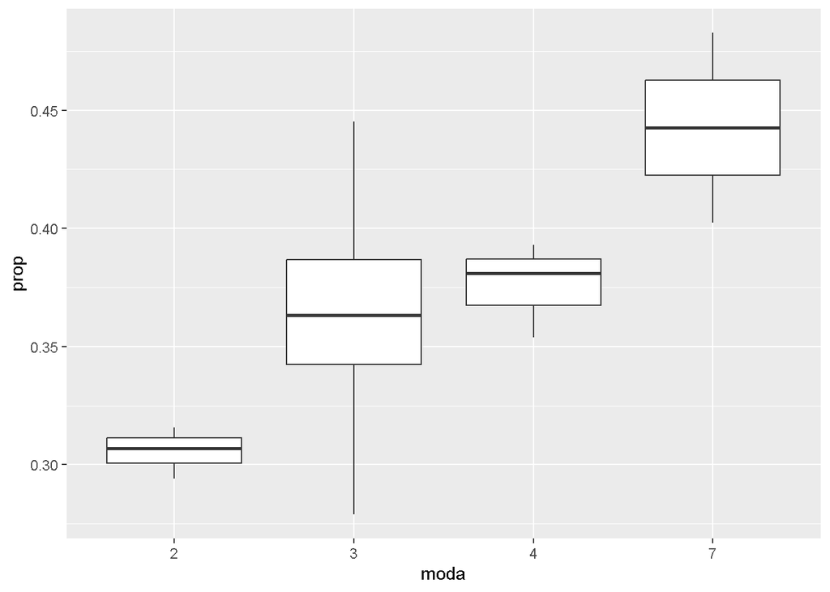

```r
full_join(comprob1, comprob2, by = "ent") %>%
  mutate(moda = as.character(moda)) %>%
  ggplot(aes(moda, prop)) +
  geom_boxplot()
```

Con la moda se confirma resultado, a mayor grado escolar mayor porcentaje de sobre-educados.

# Incidencia (2)

## Condición de informalidad

```r
ocupada %>%
  group_by(emp_ppal, edu_mis) %>%
  summarise(tot = sum(fac_tri.x)) %>%
  mutate(prop = tot / sum(tot))
```

| emp_ppal | edu_mis | tot | prop |
| --- | --- | --- | --- |
| 1 | 0 | 9825132 | 0.3014855 |
| 1 | 1 | 9455568 | 0.2901454 |
| 1 | 2 | 13308368 | 0.4083691 |
| 2 | 0 | 9081210 | 0.3381988 |
| 2 | 1 | 11706167 | 0.4359564 |
| 2 | 2 | 6064315 | 0.2258448 |

## Ámbito y tamaño de unidad económica

```r
ocupada %>%
  group_by(ambito2, edu_mis) %>%
  summarise(tot = sum(fac_tri.x)) %>%
  mutate(prop = tot / sum(tot))
```

| ambito2 | edu_mis | tot | prop |
| --- | --- | --- | --- |
| 0 | 0 | 3312745 | 0.3055559 |
| 0 | 1 | 3878873 | 0.3577736 |
| 0 | 2 | 3650080 | 0.3366705 |
| 2 | 0 | 3809248 | 0.3021748 |
| 2 | 1 | 3453111 | 0.2739237 |
| 2 | 2 | 5343748 | 0.4239015 |
| 3 | 0 | 3252749 | 0.2954088 |
| 3 | 1 | 3482780 | 0.3162998 |
| 3 | 2 | 4275480 | 0.3882914 |
| 4 | 0 | 3106409 | 0.3463947 |

[output cut: 14 more lines]

## Tipo de unidad económica

```r
ocupada %>%
  group_by(tue1, tue2, edu_mis) %>%
  summarise(tot = sum(fac_tri.x)) %>%
  mutate(prop = tot / sum(tot))
```

| tue1 | tue2 | edu_mis | tot | prop |
| --- | --- | --- | --- | --- |
| 1 | 1 | 0 | 6004402 | 0.3582075 |
| 1 | 1 | 1 | 6842971 | 0.4082344 |
| 1 | 1 | 2 | 3914983 | 0.2335580 |
| 1 | 2 | 0 | 4222217 | 0.2925538 |
| 1 | 2 | 1 | 5251840 | 0.3638955 |
| 1 | 2 | 2 | 4958220 | 0.3435508 |
| 2 | 3 | 0 | 373337 | 0.3501491 |
| 2 | 3 | 1 | 460107 | 0.4315298 |
| 2 | 3 | 2 | 232779 | 0.2183211 |
| 2 | 4 | 0 | 1858149 | 0.3121460 |

[output cut: 14 more lines]

## Migración

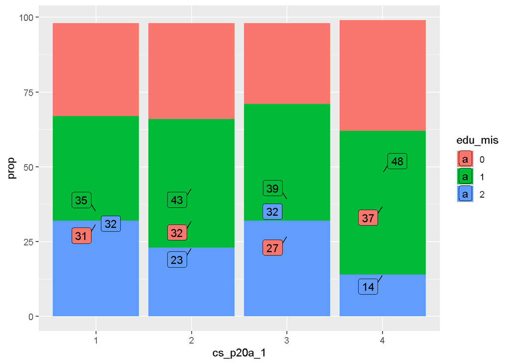

```r
library(ggrepel)

ocupada %>%
  group_by(cs_p20a_1, edu_mis) %>%
  summarise(tot = sum(fac_tri.x)) %>%
  mutate(
    prop = tot / sum(tot) * 100,
    edu_mis = factor(edu_mis),
    prop = as.integer(prop)
  ) %>%
  ggplot(aes(cs_p20a_1, prop, fill = edu_mis)) +
  geom_col() +
  ggrepel::geom_label_repel(aes(label = prop))
```

No me gusta como se ve la etiqueta dentro de la gráfica asimismo debo convertir la variable `prop` a entero (`integer`); por ende sólo lo pondré para temas de análisis.

Las personas que migraron desde otro estado (2) y de otro país (4) tienen mayor proporción de sobre-educación: 43 y 48%, respectivamente. Entonces, migrar supone una desventaja para conseguir un puesto acorde a la formación.

## Causas de migración

```r
ocupada %>%
  group_by(cs_p20c_1, edu_mis) %>%
  summarise(tot = sum(fac_tri.x)) %>%
  mutate(prop = tot / sum(tot)) %>%
  filter(edu_mis == 1) %>%
  arrange(desc(prop))
```

| cs_p20c_1 | edu_mis | tot | prop |
| --- | --- | --- | --- |
| 5 | 1 | 5675 | 0.7082241 |
| 7 | 1 | 1368 | 0.5994741 |
| 6 | 1 | 4118 | 0.5725806 |
| 9 | 1 | 772 | 0.5000000 |
| 11 | 1 | 40196 | 0.4776141 |
| 2 | 1 | 37506 | 0.4684853 |
| 3 | 1 | 64384 | 0.4671126 |
| 1 | 1 | 62249 | 0.4265880 |
| 10 | 1 | 3254 | 0.4045251 |
| 4 | 1 | 17772 | 0.3872570 |

[output cut: 1 more lines]

De las personas que reportaron migrar por motivos de estudio (5), el 70% se encuentra sobre-educado mientras que los que migraron para buscar trabajo el 43% está sobre-educado, y por cambio u oferta de trabajo el 47% (2) lo está.

## Total de trabajos

```r
ocupada %>%
  group_by(t_tra, edu_mis) %>%
  summarise(tot = sum(fac_tri.x)) %>%
  mutate(prop = tot / sum(tot))
```

| t_tra | edu_mis | tot | prop |
| --- | --- | --- | --- |
| 1 | 0 | 18038877 | 0.3200274 |
| 1 | 1 | 20035106 | 0.3554424 |
| 1 | 2 | 18292689 | 0.3245302 |
| 2 | 0 | 867465 | 0.2821861 |
| 2 | 1 | 1126629 | 0.3664921 |
| 2 | 2 | 1079994 | 0.3513218 |

No existen diferencias en la proporción de sobre-educados cuando se tiene 1 o 2 trabajos. ¿Por qué? Acaso, será la jornada laboral.

```r
ocupada %>%
  group_by(dur_est, edu_mis) %>%
  summarise(tot = sum(fac_tri.x)) %>%
  mutate(prop = tot / sum(tot),
         edu_mis = factor(edu_mis)) %>%
  filter(edu_mis == 0)
```

| dur_est | edu_mis | tot | prop |
| --- | --- | --- | --- |
| 1 | 0 | 439639 | 0.3271201 |
| 2 | 0 | 1037930 | 0.2649110 |
| 3 | 0 | 3409739 | 0.3096206 |
| 4 | 0 | 9209733 | 0.3284082 |
| 5 | 0 | 4561654 | 0.3191868 |
| 6 | 0 | 247647 | 0.2979814 |

```r
  # ggplot(aes(dur_est, prop, fill = edu_mis)) +
  # geom_col() +
  # scale_y_continuous(breaks = seq(0, 1, by = 0.1))
```

No existen diferencias significativas en cuanto a la duración de la jornada laboral. ¿Al revés?

```r
ocupada %>%
  group_by(edu_mis, t_tra) %>%
  summarise(tot = sum(fac_tri.x)) %>%
  mutate(prop = tot / sum(tot))
```

| edu_mis | t_tra | tot | prop |
| --- | --- | --- | --- |
| 0 | 1 | 18038877 | 0.95411778 |
| 0 | 2 | 867465 | 0.04588222 |
| 1 | 1 | 20035106 | 0.94676103 |
| 1 | 2 | 1126629 | 0.05323897 |
| 2 | 1 | 18292689 | 0.94425171 |
| 2 | 2 | 1079994 | 0.05574829 |

De los que están sobre-educados, sólo el 5% tiene 2 trabajos. ¿Qué dicen acerca de la búsqueda de trabajo?

## Búsqueda de otro empleo

```r
ocupada %>%
  group_by(edu_mis, buscar5c) %>%
  summarise(tot = sum(fac_tri.x)) %>%
  mutate(prop = tot / sum(tot))
```

| edu_mis | buscar5c | tot | prop |
| --- | --- | --- | --- |
| 0 | 1 | 119887 | 0.0063410997 |
| 0 | 2 | 327827 | 0.0173395255 |
| 0 | 3 | 101548 | 0.0053711077 |
| 0 | 4 | 18342993 | 0.9702031731 |
| 0 | 5 | 14087 | 0.0007450939 |
| 1 | 1 | 121013 | 0.0057184820 |
| 1 | 2 | 492286 | 0.0232630264 |
| 1 | 3 | 148686 | 0.0070261725 |
| 1 | 4 | 20379795 | 0.9630493435 |
| 1 | 5 | 19955 | 0.0009429756 |

[output cut: 5 more lines]

## Nivel de ingreso

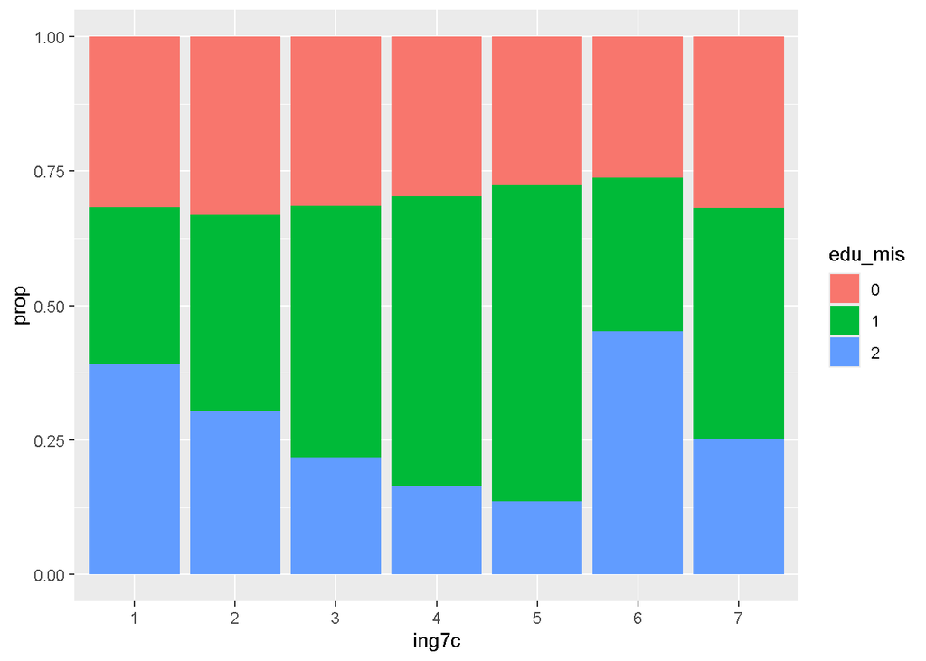

```r
ocupada %>%
  group_by(ing7c, edu_mis) %>%
  summarise(tot = sum(fac_tri.x)) %>%
  mutate(prop = tot / sum(tot),
    edu_mis = factor(edu_mis)) %>%
  ggplot(aes(ing7c, prop, fill = edu_mis)) +
    geom_col()
```

Se presenta mayor porcentaje de sobre-educados en el nivel de ingreso de más de 5 salarios mínimos, es decir, a medida que incrementa el nivel de ingreso también aumenta la proporción de sobre-educados. Esto pone en duda la metodología empleada para determinar la sobre-educación.

## Ingreso mensual

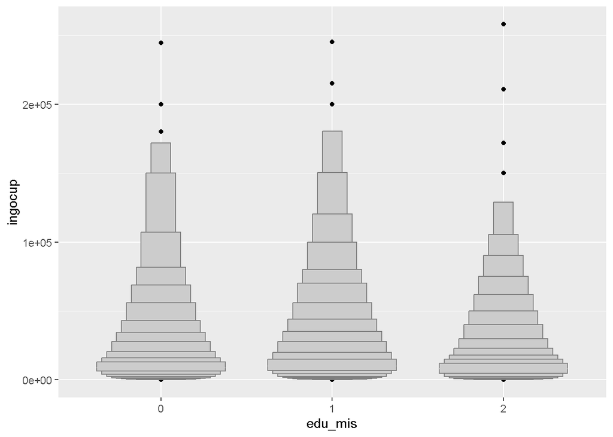

```r
ocupada %>%
  filter(ingocup != 0) %>%
  mutate(edu_mis = factor(edu_mis)) %>%
  ggplot(aes(edu_mis, ingocup)) +
  geom_lv()
```

No se observan cambios significativos de ajustados a sobre-educados, incluso se observa que la mediana de sobre-educación es superior que ajustados. ¿Cómo es en el caso de jóvenes?

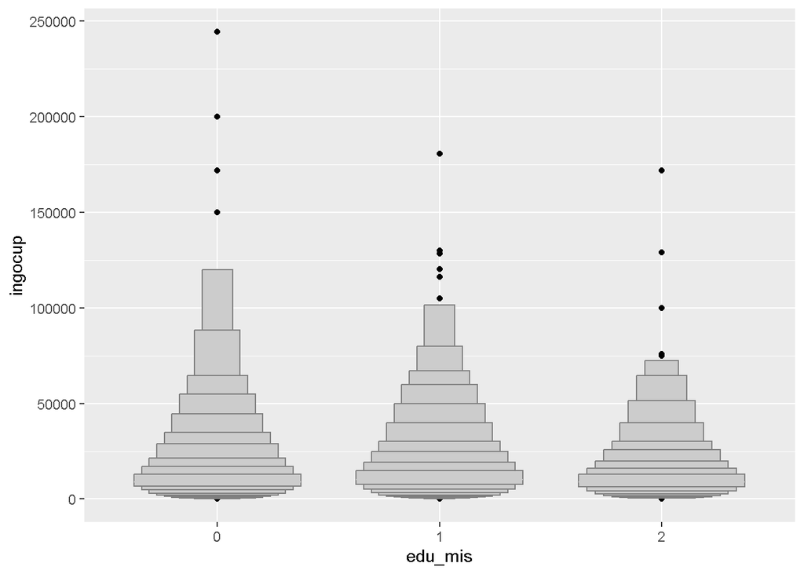

```r
ocupada %>%
  filter(edad_7g == 3 & ingocup != 0) %>%
  mutate(edu_mis = factor(edu_mis)) %>%
  ggplot(aes(edu_mis, ingocup)) +
  geom_lv()
```

Los valores extremos se presentan en el caso de ajustados, pero de nuevo la mediana de sobre-educación es superior al de ajustados.

### Profesionistas

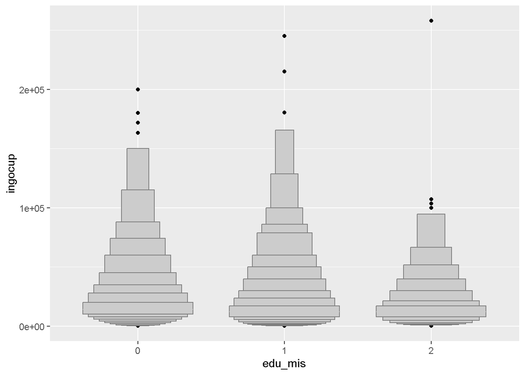

```r
ocupada %>%
  filter(cs_p13_1 == 7 & ingocup != 0) %>%
  mutate(edu_mis = factor(edu_mis)) %>%
  ggplot(aes(edu_mis, ingocup)) +
  geom_lv()
```

La mediana de requeridos es mayor al de sobre-educación, pero éste último presenta mayores valores extremos

### Jóvenes profesionistas

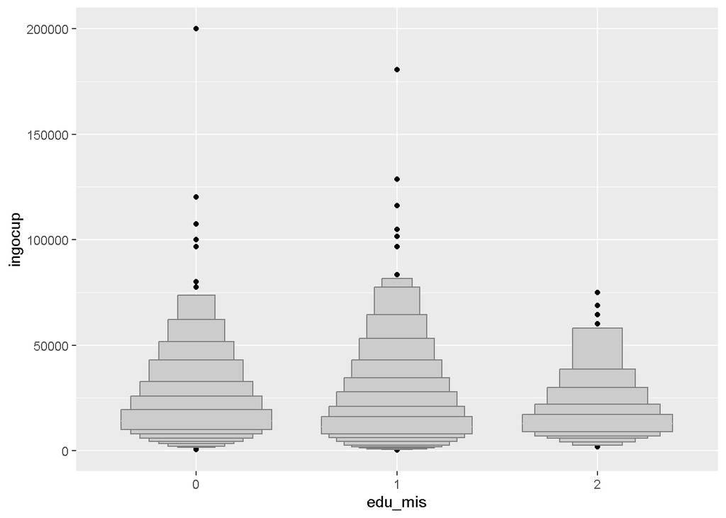

```r
ocupada %>%
  filter(cs_p13_1 == 7 & edad_7g == 3 & ingocup != 0) %>%
  mutate(edu_mis = factor(edu_mis)) %>%
  ggplot(aes(edu_mis, ingocup)) +
  geom_lv()
```

### Promedio de Total

```r
ocupada %>%
  filter(ingocup != 0) %>%
  mutate(edu_mis = factor(edu_mis)) %>%
  group_by(edu_mis) %>%
  summarise(
    media = mean(ingocup),
    mediana = median(ingocup)
  )
```

| edu_mis | media | mediana |
| --- | --- | --- |
| 0 | 10401.130 | 8600 |
| 1 | 12367.052 | 10000 |
| 2 | 9077.622 | 8000 |

El ingreso mensual promedio es superior en el caso de sobre-educados que ajustados.

### Promedio de Profesionistas

```r
ocupada %>%
  mutate(
    edu_mis = factor(edu_mis),
    cs_p13_1 = as.integer(cs_p13_1)
  ) %>%
  filter(between(cs_p13_1, 7, 9) & ingocup != 0) %>%
  mutate(edu_mis = factor(edu_mis)) %>%
  group_by(edu_mis) %>%
  summarise(
    media = mean(ingocup),
    mediana = median(ingocup)
  )
```

| edu_mis | media | mediana |
| --- | --- | --- |
| 0 | 17401.18 | 14000 |
| 1 | 14994.28 | 12000 |
| 2 | 14112.94 | 12000 |

En el caso de profesionistas, el ingreso mensual de ajustados es superior al de sobre-educados considerando licenciatura, maestría y doctorado.

### Promedio de Jóvenes

```r
ocupada %>%
  mutate(
    edu_mis = factor(edu_mis),
    cs_p13_1 = as.integer(cs_p13_1)
  ) %>%
  filter(edad_7g == 3 & ingocup != 0) %>%
  mutate(edu_mis = factor(edu_mis)) %>%
  group_by(edu_mis) %>%
  summarise(
    media = mean(ingocup),
    mediana = median(ingocup)
  )
```

| edu_mis | media | mediana |
| --- | --- | --- |
| 0 | 10967.23 | 9030 |
| 1 | 12214.47 | 10320 |
| 2 | 10487.74 | 9030 |

En el caso de jóvenes, el ingreso mensual promedio de sobre-educados es superior al de ajustados.

### Promedio de Jóvenes profesionistas

```r
ocupada %>%
  mutate(
    edu_mis = factor(edu_mis),
    cs_p13_1 = as.integer(cs_p13_1)
  ) %>%
  filter(between(cs_p13_1, 7, 9) & edad_7g == 3 & ingocup != 0) %>%
  mutate(edu_mis = factor(edu_mis)) %>%
  group_by(edu_mis) %>%
  summarise(
    media = mean(ingocup),
    mediana = median(ingocup)
  )
```

| edu_mis | media | mediana |
| --- | --- | --- |
| 0 | 16352.32 | 14000 |
| 1 | 13790.22 | 12000 |
| 2 | 14859.16 | 12685 |

Para el caso de jóvenes profesionistas (licenciatura, maestría y doctorado) de 25 a 34 años, el ingreso mensual promedio con sobre-educación es menor al de ajustados.

# Relación entre ingreso promedio y

## grupos de edad

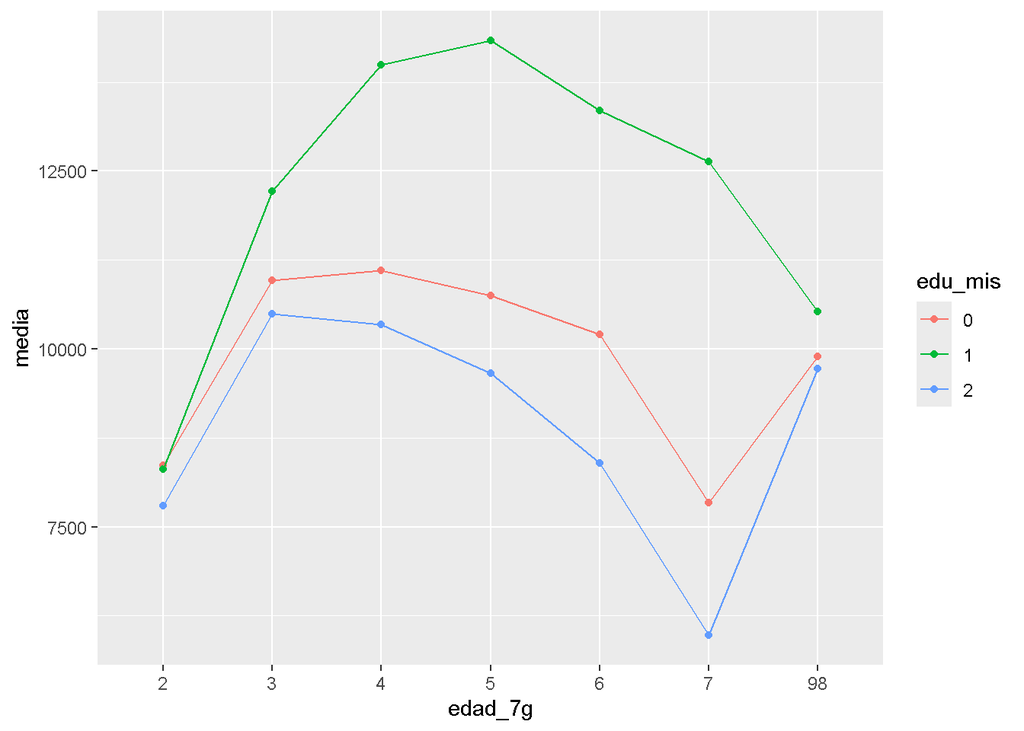

```r
ocupada %>%
  mutate(
    edu_mis = factor(edu_mis),
    cs_p13_1 = as.integer(cs_p13_1)
  ) %>%
  filter(ingocup != 0) %>%
  mutate(edu_mis = factor(edu_mis)) %>%
  group_by(edad_7g, edu_mis) %>%
  summarise(
    media = mean(ingocup),
    mediana = median(ingocup)
  ) %>%
  ggplot(aes(edad_7g, media, color = edu_mis, group = edu_mis)) +
  geom_point() +
  geom_line()
```

## grado escolar

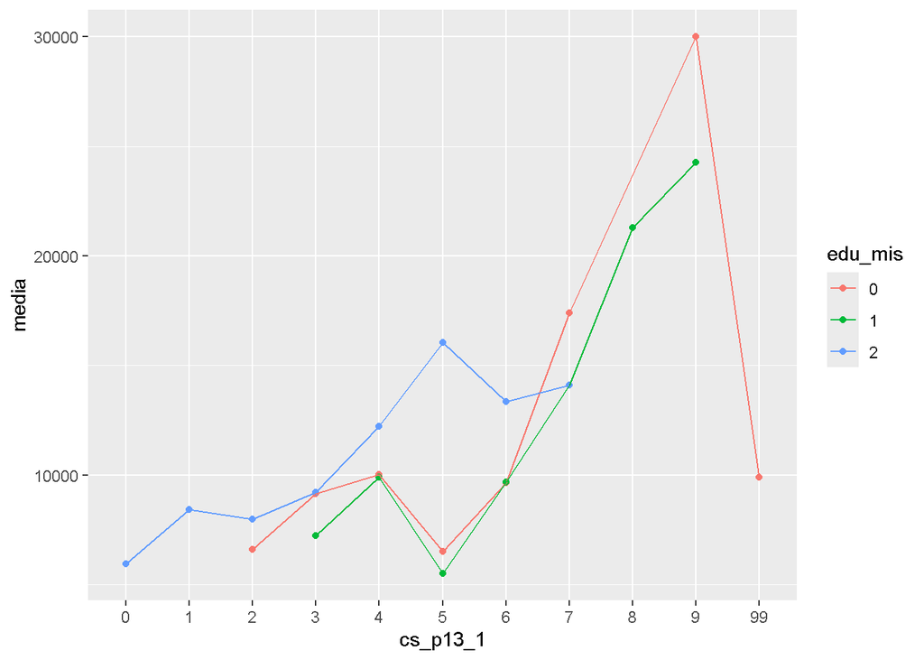

```r
ocupada %>%
  mutate(
    edu_mis = factor(edu_mis),
    cs_p13_1 = factor(cs_p13_1)
  ) %>%
  filter(ingocup != 0) %>%
  mutate(edu_mis = factor(edu_mis)) %>%
  group_by(cs_p13_1, edu_mis) %>%
  summarise(
    media = mean(ingocup),
    mediana = median(ingocup)
  ) %>%
  ggplot(aes(cs_p13_1, media, color = edu_mis, group = edu_mis)) +
  geom_point() +
  geom_line()
```

Por grado escolar, se observa que el ingreso mensual promedio de sobre-educación es menor al ajustado desde el grado profesional.

## años escolares

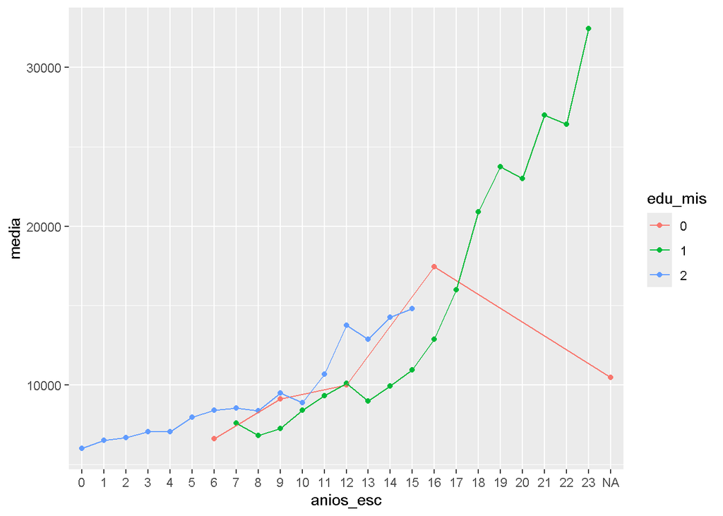

```r
ocupada %>%
  mutate(
    edu_mis = factor(edu_mis),
    anios_esc = factor(anios_esc)
  ) %>%
  filter(ingocup != 0) %>%
  mutate(edu_mis = factor(edu_mis)) %>%
  group_by(anios_esc, edu_mis) %>%
  summarise(
    media = mean(ingocup),
    mediana = median(ingocup)
  ) %>%
  ggplot(aes(anios_esc, media, color = edu_mis, group = edu_mis)) +
  geom_point() +
  geom_line()
```

Por años de escolaridad, se observa que desde el año 18 el ingreso mensual promedio de sobre-educación es superior al de ajustados.

## Explicación

Esta situación puede presentarse por determinar de forma errónea los años de educación requeridos en cada ocupación. Se puede solucionar de dos maneras:

1. Construir los años requeridos con la variable `p3`.
2. Elegir otro método, por ejemplo el de Verdugo and Verdugo (1989).

# Resumen

En conclusión, puedo decir que con el método de la moda el ingreso mensual promedio de sobre-educación es superior al de ajustados; puede deberse a errores metodológicos, es decir, las personas consideradas como sobre-educadas en realidad no lo están por ende no se ve afectado su ingreso.

# Referencias

INEGI. 2023. *Encuesta Nacional de Ocupación y Empleo. ENOE. Conociendo La Base de Datos.*

INEGI. 2025. *Encuesta Nacional de Ocupación y Empleo (ENOE). Segundo Trimestre de 2025*.

Verdugo, Richard R., and Naomi Turner Verdugo. 1989. “The Impact of Surplus Schooling on Earnings: Some Additional Findings.” *The Journal of Human Resources* 24 (4): 629–43. https://doi.org/10.2307/145998.